# Assignment 7 - Answers

Bernell Downer

11/30/2016

In the following assignment you will be looking at data from an one level of an online geography tutoring system used by 5th grade students. The game involves a pre-test of geography knowledge (pre.test), a series of assignments for which you have the average score (av.assignment.score), the number of messages sent by each student to other students about the assignments (messages), the number of forum posts students posted asking questions about the assignment (forum.posts), a post test at the end of the level (post.test) and whether or not the system allowed the students to go on to the next level (level.up).

## Part I

#Upload data

```r
D1 <- read.csv("online.data.csv", header = TRUE)
```

#Visualization

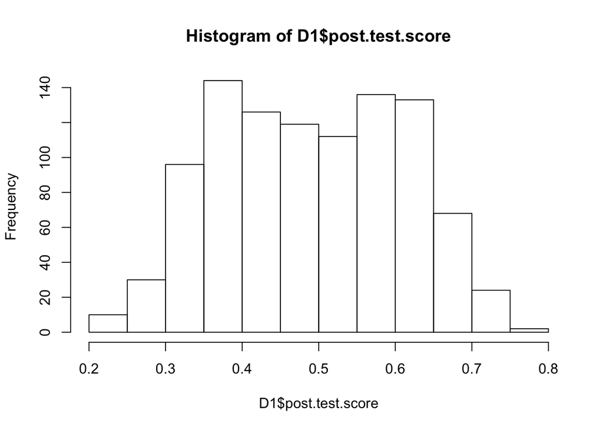

```r
#Start by creating histograms of the distributions for all variables (#HINT: look up "facet" in the ggplot documentation)

#Convert "yes" & "no" to 1 & 0, respectively, for level.up entries
D1$level.up <- ifelse(D1$level.up == "yes", 1,0)

hist(D1$post.test.score)
```

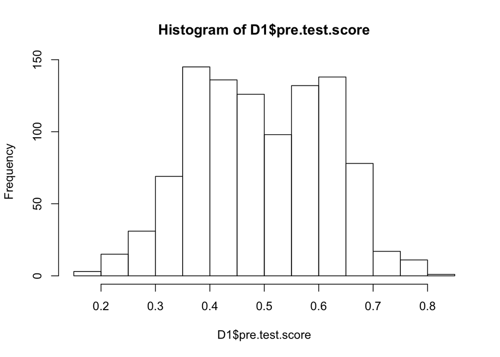

```r
hist(D1$pre.test.score)
```

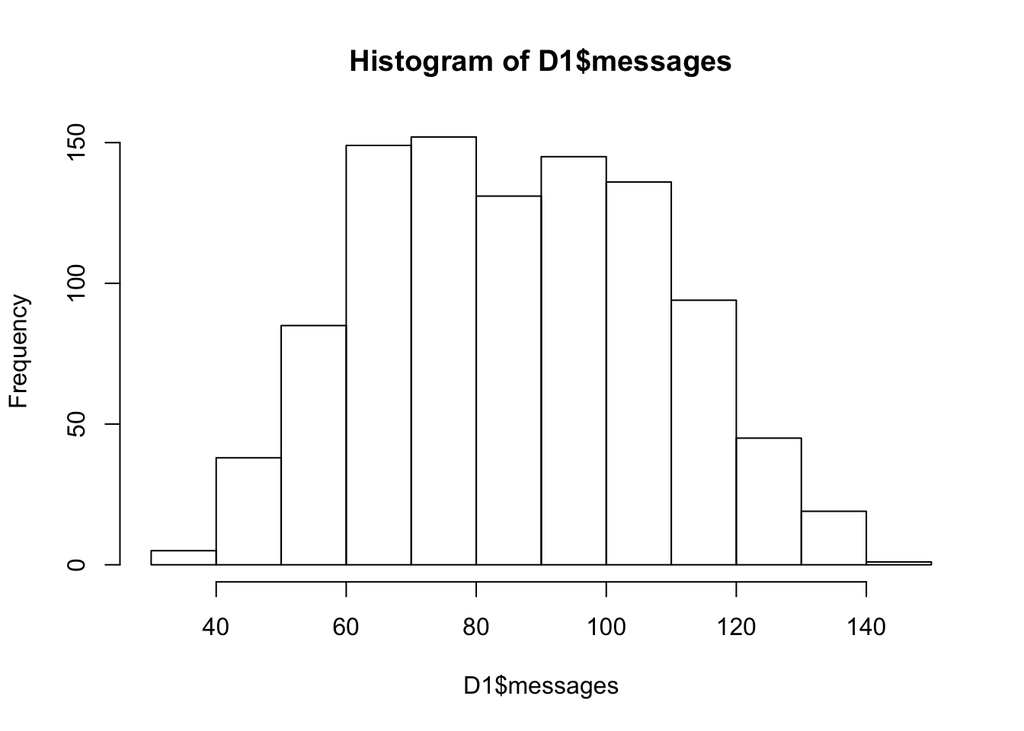

```r
hist(D1$messages)
```

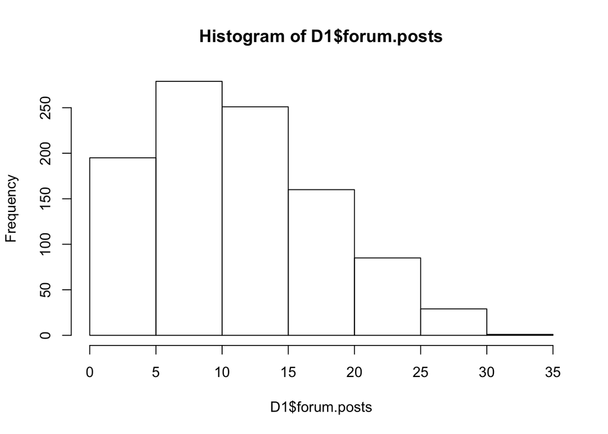

```r
hist(D1$forum.posts)
```

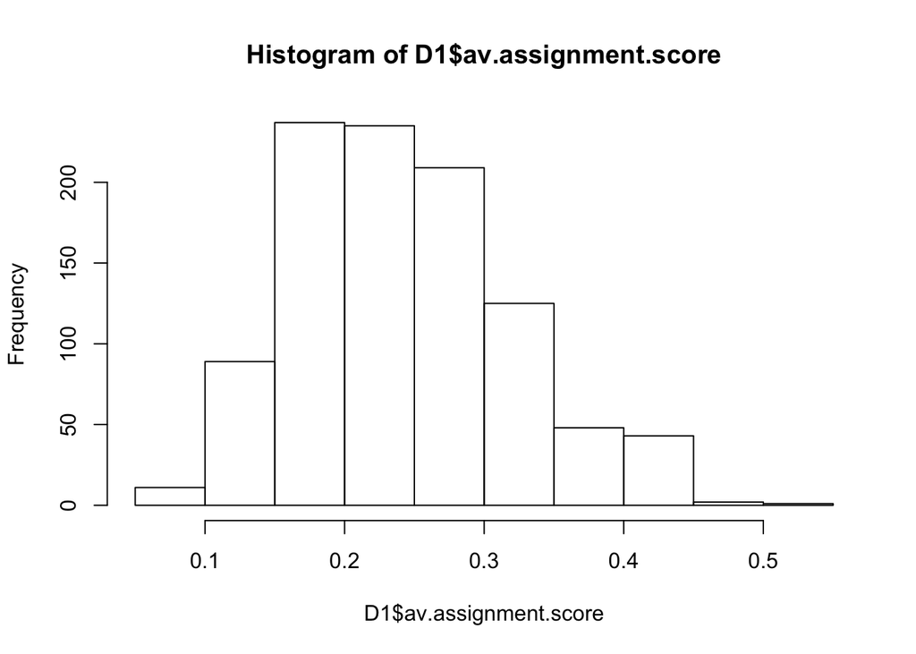

```r
hist(D1$av.assignment.score)
```

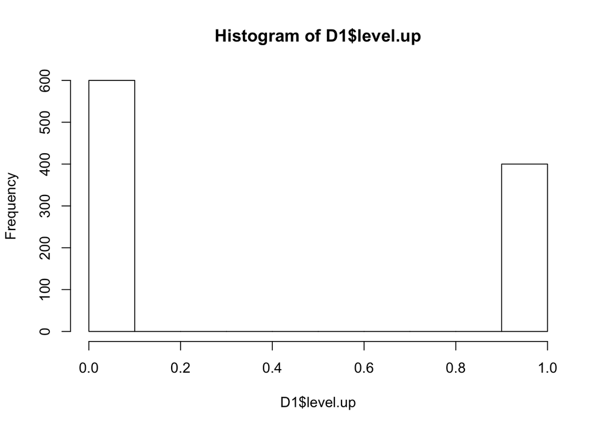

```r
hist(D1$level.up)
```

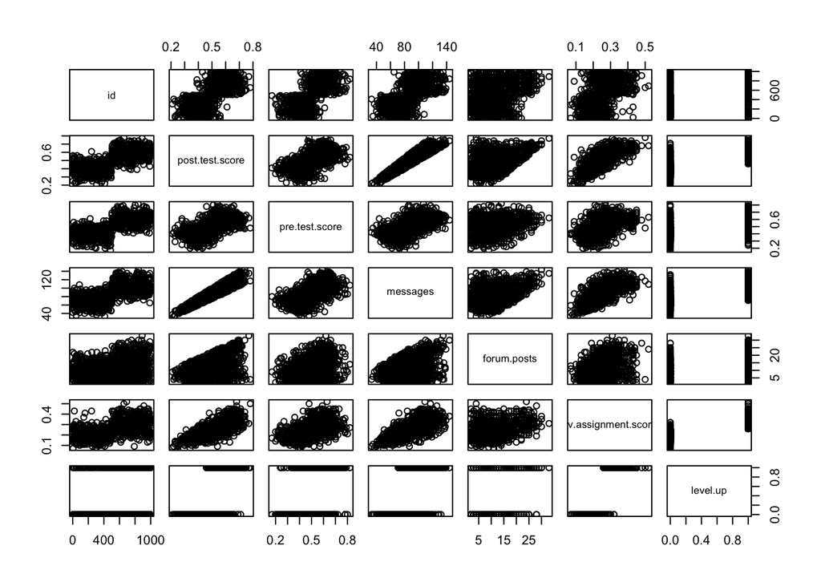

```r
#Visualize the relationships between variables
pairs(D1)
```

```r
#Try to capture an intution about the data and the relationships

library(dplyr)
library(tidyr)

D2 <- gather(D1, "measure", "score", 2:7)
```

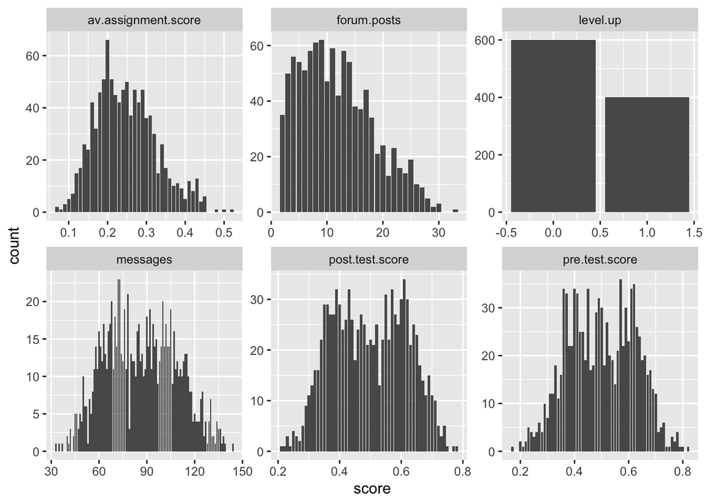

```r
library(ggplot2)
p1 <- ggplot(D2, aes(score)) + facet_wrap(~measure, scales = "free")
p1 + geom_histogram(stat = "count")
```

#Classification tree

[figure not shown]

```r
#Create a classification tree that predicts whether a student "levels up" in the online course using three variables of your choice (As we did last time, set all controls to their minimums)

library(rpart)
c.tree1 <- rpart(level.up ~ pre.test.score + av.assignment.score + forum.posts, method = "class", data = D1)

#Plot your tree
plot(c.tree1)
```

```r
post(c.tree1, file = "tree1.ps", title = "ONLINE") #This creates a pdf image of the tree
```

```r
#Generate a CP table for your tree
printcp(c.tree1)
```

```
##
## Classification tree:
## rpart(formula = level.up ~ pre.test.score + av.assignment.score +
##     forum.posts, data = D1, method = "class")
##
## Variables actually used in tree construction:
## [1] av.assignment.score
##
## Root node error: 400/1000 = 0.4
##
## n= 1000
##
##     CP nsplit rel error xerror     xstd
## 1 0.93      0      1.00   1.00 0.038730
## 2 0.01      1      0.07   0.07 0.013042
```

```r
#Generate a probability value that represents the probability that a student levels up based your classification tree

c.tree2 <- prune(c.tree1, cp = 0.01)#Set cp to the level at which you want the tree to end

D1$pred <- predict(c.tree2, type = "prob")[,2]#Last class we used type = "class" which predicted the classification for us, this time we are using type = "prob" to see the probability that our classififcation is based on.
```